跳至主要內容

# 多變量分析（區別分析）

LDA／QDA Skill｜流程設計與實作驗證

發佈於

2026年11月12日

LDA／QDA 半自動化決策 分層交叉驗證 R 實際計算 可重現報告

從資料檢查、假設診斷到模型比較，建立一套能說明「為什麼這樣分析」的區別分析 Skill。本報告介紹設計邏輯、決策關卡與實際驗證成果。

## 拿到這樣的資料，就可以用這個 skill

| Sepal.Length | Sepal.Width | Petal.Length | Petal.Width | Species |
| --- | --- | --- | --- | --- |
| 5.1 | 3.5 | 1.4 | 0.2 | setosa |
| 7.0 | 3.2 | 4.7 | 1.4 | versicolor |
| 6.3 | 3.3 | 6.0 | 2.5 | virginica |
| … | … | … | … | … |

這份資料（iris 的第 1、51、101 筆）有三個特徵，也就是適合使用這個 skill 的條件：

- **最後一欄是已知的類別**（Y）：每朵花是哪個品種已經知道；
- **前面幾欄都是連續的測量值**（X）：長度、寬度；
- **每一列是不同的對象**：一列就是一朵花。

你的資料也長這樣，就可以用這個 skill：它用 LDA 與 QDA 建立分類規則，檢查兩者的假設，用重複交叉驗證公平比較，最後交付一份看得懂、說清楚限制的中文報告。什麼情況特別適合、什麼情況該改用其他方法，見第 06 節。

**它不是「挑出最準模型」的工具箱，而是把 LDA／QDA 做深、做對、講清楚的分析助理。**

第一部分｜認識 LDA／QDA

## 01｜要解決什麼問題

很多時候我們想用幾個測量值，判斷一個樣本屬於哪一類：

| 領域 | 用什麼判斷 | 判斷成哪一類 |
| --- | --- | --- |
| 生物 | 花萼、花瓣的長度與寬度 | 鳶尾花的品種 |
| 醫學 | 血糖、血壓等檢驗值 | 有病／沒病 |
| 金融 | 收入、負債、消費紀錄 | 信用好／普通／差 |

這些問題有共同的結構：

- 資料已經有**已知的類別**（例如已經知道每朵花的品種），所以這是「監督式」分類。
- 每個樣本同時有好幾個測量值，要一起考慮。
- 目標是建立一條**分類規則**，讓新的樣本也能被分到最可能的類別。

區別分析（Discriminant Analysis）就是處理這類問題的經典方法，LDA 與 QDA 是其中最常用的兩種。

## 02｜核心想法

區別分析可以從兩個角度理解：角度一主要說明 LDA；角度二是 LDA 與 QDA 共同的基礎。

### 角度一：找到最能分開類別的方向（Fisher, 1936；對應 LDA）

好幾個變數很難一眼看出差異，那就把它們**加權組合成一個新分數**。權重要選得好，讓不同類別在這個分數上：

- 平均值離得越遠越好（組間差異大）
- 同一類內部越集中越好（組內差異小）

這個分數叫**判別分數**，也能把高維資料壓到低維，畫成圖觀察類別怎麼分開。

### 角度二：分到機率最大的那一類（Bayes 規則）

對一個新樣本，算出它屬於每一類的機率，分到機率最大的那一類。這個機率由兩件事決定：

- 這一類本來就占多少比例（先驗機率）
- 如果樣本屬於這一類，看到這組測量值的可能性有多大

在「每種分錯的代價都一樣」時，這條規則能讓**平均分錯的機率最小**。但「看到這組測量值的可能性」實際上不知道，需要另外估計；LDA、QDA 的做法是假設每一類是鐘形分布（多元常態），兩者的差別在下一節的第二個假設。

### 兩個角度的關係

Fisher 只找「怎麼組合變數最能分開類別」，不需要假設資料的形狀；Bayes 規則本身也不限定資料的分布。LDA 是 Bayes 規則再加上「每一類是鐘形、而且散開的大小和方向相同」，這時它找到的方向和 Fisher 一樣。QDA 允許各類散開的方式不同，分界是曲線，沒有這樣一組共用的方向。

## 03｜兩個基本假設

| 假設 | 白話意思 | 怎麼檢查 |
| --- | --- | --- |
| 多元常態 | 每一類的資料，形狀大致是「中間多、兩邊少」的鐘形（多個變數一起看） | Mardia 檢定、Q-Q 圖 |
| 共變異數是否相同 | 每一類資料「散開的大小和方向」是不是一樣 | Box’s M 檢定 |

注意：每個變數**各自**看起來像常態，不代表它們**合起來**是多元常態，所以要用 Mardia 這類多變量檢定一起檢查。

共變異數的假設是區分 LDA 與 QDA 的地方，下一節說明兩者的差別。

## 04｜LDA 與 QDA

|  | LDA（線性區別分析） | QDA（二次區別分析） |
| --- | --- | --- |
| 假設 | 各類共變異數矩陣**相同** | 各類共變異數矩陣**可以不同** |
| 分界線 | 直線（變數多時是平面） | 曲線（例如橢圓、拋物線） |
| 分類方式 | 對每一類算一個分數，分到分數最高的類別 | 同左 |

可以想像成：LDA 只能用尺畫直線把類別分開；QDA 可以畫彎的線，所以遇到形狀差很多的類別時更有彈性。

## 05｜LDA 與 QDA 的取捨

|  | LDA | QDA |
| --- | --- | --- |
| 要估計的東西 | 少 | 多（每一類都要各自估計共變異數矩陣） |
| 資料需求 | 較少也能用 | 每一類的樣本數必須多於變數個數 |
| 優點 | 簡單、穩定，還能畫判別分數圖 | 彈性大，能處理各類形狀差很多的資料 |
| 風險 | 形狀真的差很多時分不好 | 資料少時估計不穩，容易「背答案」 |

QDA 需要為每一類各自估計共變異數，要估計的參數比 LDA 多很多，因此對樣本數的要求也比較高。

**從方法到 skill**  
一種常見做法是先看 Box’s M 檢定再決定。但 Box’s M 對偏離常態很敏感，而且 QDA 多估的那些數值，不一定換得到更好的分類。所以接下來介紹的 skill，會讓兩種方法用同一套 test set 檢驗，看誰實際分得比較準。

第二部分｜LDA／QDA Skill

## 06｜什麼情境選這個 skill

`lda-qda` 協助使用者以已知類別 Y 與數值型 X 建立分類模型。使用者確認研究問題與欄位；AI 依規則安排流程，R 程式負責計算，最後交付中文解讀與可重現結果。

### 情境與理由

| 情境 | 為什麼選 LDA／QDA（本 skill） | 換成其他方法會遇到的問題 |
| --- | --- | --- |
| **樣本數不多**，每類幾十筆，且各類大致是鐘形 | LDA 只需估計各類平均和一個共同的共變異數矩陣，小樣本也穩定；QDA 需要較多資料，skill 會用交叉驗證比較兩者，資料不夠時通常 LDA 勝出 | **KNN、隨機森林、SVM**：需要較多資料才能學出好的界線，資料少時容易過度配適 |
| **3 類以上** | LDA 和 QDA 都直接處理多類；LDA 還能把資料投影到判別軸上，一張圖看出類別怎麼分開 | **邏輯斯迴歸**：要擴充成多項模型，係數都是「相對於基準類」，解釋較繞 |
| **需要解釋結果**，例如課堂報告、向非統計背景的人說明 | 有判別分數圖（見第 11 節圖 4），看得到哪些類別重疊；每筆資料屬於各類的機率另存成檔案 | **KNN、隨機森林、SVM**：較像黑盒子，只給答案，很難說明是怎麼分的 |
| **需要檢查假設、說清楚結論能說到多滿** | 有明確的模型假設，可以檢查常態與共變異數是否相同，並說明對結果的影響 | 機器學習方法多半沒有可檢查的分布假設，只能看預測分數 |

### 這些情況，其他方法比較好

| 情境 | 建議改用 |
| --- | --- |
| 資料量很大、類別界線很不規則 | KNN、隨機森林、SVM |
| X 主要是類別型，例如性別、地區 | 邏輯斯迴歸、決策樹 |
| 只在乎預測最準，不需要解釋 | 多種機器學習方法一起比較 |

表中的其他方法是一般建議，本 skill 不會執行。另外，第一版只處理**獨立觀測**：群組、重複測量及時間資料的專用切分（分組驗證、時間切分）尚未實作，遇到這類結構時**暫停**，先確認研究單位，不直接套用隨機分層驗證。

> **資料不多、測量值連續、類別有已知標籤，而且需要解釋和誠實說明限制**時，LDA／QDA 是最合適的起點；本 skill 把這套分析做完整，包括比較、檢查假設，並寫成看得懂的報告。

**設計原則：固定且可解釋的流程，只在必要時詢問，不改變研究問題。**  
Y 一定由使用者指定；AI 自動提出 X 清單，使用者確認後才執行分析。AI 不合併或刪除類別、不自行刪除資料列、不自行改模型——這些都會改變原本的研究問題；做不到就停止並說明原因。X 的遺失值只在使用者同意後，以各訓練折的中位數補值；Y 有缺失就停止。離群只標記；完全相同的列預設保留，只有使用者確認是重複登錄才刪除。

**使用者｜研究與決策**

確認目的、變數意義、單位與需要處理的資料問題。

**AI｜流程與解讀**

依 Skill 選擇下一步，讀取參考文件，說明結果與限制。

**R｜計算與保存**

配適模型、執行診斷、保存折別與折外預測，確保數字有依據。

## 07｜完整分析流程

左邊是主流程，右邊是會停下來或自動處理的地方。資料乾淨時（例如 iris），確認完 Y 和 X 就一路跑完，不會再停下來。

[figure not shown]

圖 1 LDA／QDA skill 的分析流程。每一列右側是可能的結果：藍綠色是會停下來詢問使用者的關卡，灰色虛線框是停止或暫停並說明原因，黃色是不詢問、自動處理並在報告中註明的情況；括號內是下方關卡表的代號。虛線箭頭：決定補值後重新執行分析。

### 詢問與停止的關卡

每個關卡都用白話說明原因。AI **不**合併或刪除類別、**不**自行刪除資料列、**不**自行修改模型；做不到就停止並說明，由使用者決定下一步。

| 關卡 | 什麼時候 | 為什麼要問 | 選項 |
| --- | --- | --- | --- |
| A | 沒指定要分類的欄位（Y） | 要分什麼類是研究問題本身，只能由你決定 | **詢問**，列出候選欄位讓你點選，不猜測 |
| B | 確認用來判斷的欄位（X） | 有些欄位不該拿來用，例如編號、結果發生後才知道的資訊 | 列出預設清單，你只要按「照這樣用」或修改。名稱就是編號（如 id）的欄位自動排除；數值看起來像編號（每筆都不同的整數）的欄位保留並標出來請你確認，**不自行刪除** |
| C | 疑似同一對象有多筆（偵測到重複的編號、日期欄位、完全相同的列超過 5%，或你描述為多次紀錄） | 同一個人可能同時出現在 train set 和 test set，分數會灌水；本版沒有分組驗證 | **暫停**：先確認研究單位，確認每一列是獨立個體後才繼續。若是因完全相同的列偏多而暫停：選「不同對象，保留」或「重複登錄，刪除」 |
| D | 資料有遺失值 | 模型沒辦法處理遺失值 | **X 有遺失值**：先報告遺失值數量與位置，再問：⭐ 補中位數（只用每份 train set 計算）／停止分析。**Y 有遺失值**：停止並列出是哪幾列，不補、不猜，由你確認後再執行 |
| E | 某一類少於 5 筆 | 分層 5-fold 需要每一類至少 5 筆 | **停止**並說明哪一類不足；不減少折數、不合併或刪除類別 |
| F | LDA、QDA 都算不出來 | 通常是某個欄位可以由其他欄位算出來（例如同時有公分和公尺，或總分＝各科相加），或總筆數相對欄位數太少，導致共變異數矩陣無法計算 | **停止**並說明原因，由你決定要不要換一組 X 重新執行 |

### 不問你、自動處理的情況

| 情況 | 怎麼處理 |
| --- | --- |
| 只有 QDA 算不出來 | 只評估 LDA，並在報告說明原因 |
| 常數欄位、名稱就是編號（如 id）的欄位 | 自動排除在 X 之外，報告列出原因 |
| 完全相同的列不超過 5% | 確認 X 時順帶告知，預設保留；你說是重複登錄才刪除 |
| 特別大、特別小的值 | 標記出來，但不刪除 |
| 各類別數量差很多 | Macro recall 本來就是主要指標；類別數量差很多時特別要看它，不要只看整體正確率。但它只改變評分方式：模型的先驗機率仍依類別比例估計，會偏向大類別，小類別可能還是常被分錯，報告會照實呈現 |
| 某個方法在任何一次、任何一折算不出來 | 標為「驗證不完整」，不參加比較，只評估另一個方法 |
| Mardia、Box’s M 的結果 | 寫進報告當參考，附兩者的合併解讀；Mardia 顯著時自動加註 |
| 根本不是分類問題（例如要預測身高） | 說明這個方法不適用 |

## 08｜資料探索與假設診斷

### 資料與模型設定

先整理各類別樣本數、變數分布與資料品質，再確認候選模型是否可以估計。數值型 ID、結果發生後才取得的欄位，不能只因為「可以轉成數字」就直接納入 X。

LDA／QDA 使用 `MASS::lda()` 與 `MASS::qda()`。先驗機率預設來自各訓練折的類別比例，並保存類別順序；矩陣秩不足或組內無變異時，記錄原因，不擅自刪欄或改用其他模型。

### 探索圖與假設診斷

| 檢查 | 要回答的問題 | 解讀界線 |
| --- | --- | --- |
| 分組散布圖、箱型圖 | 分布、重疊與離群外觀如何？ | 圖形提供探索線索，不直接決定刪除資料 |
| 各組 Q-Q 圖 | 個別變數的常態外觀是否合理？ | 邊際常態不能單獨證明多變量常態 |
| 各組 Mardia | 多變量偏態、峰態是否有異常訊號？ | 不顯著不等於已證明常態；保留樣本數與方法限制 |
| Box’s M | 各類共變異數矩陣相同嗎？ | 資料不像鐘形時容易顯著，要搭配 Mardia 解讀 |
| 常數、線性相依與樣本量 | 模型及各訓練折能否估計？ | 可行性須逐模型、逐訓練折檢查 |

### Mardia 與 Box’s M 要一起看

Box’s M 的結論依賴常態假設，所以兩個檢定合起來解讀。報告會附這張表，標出資料落在哪一格：

| Mardia | Box’s M | 解讀 |
| --- | --- | --- |
| 不顯著 | 不顯著 | 未發現明顯違反假設；仍依交叉驗證結果選方法 |
| 不顯著 | 顯著 | 各類共變異數可能不同，QDA 有機會較好 |
| 顯著 | 不顯著 | 資料不像鐘形，算出的機率可能不準 |
| 顯著 | 顯著 | Box’s M 可能只是受非鐘形影響，不能直接下結論 |

任何一類的 Mardia 顯著時，報告會自動加註：即使資料不符合多元常態，仍可用交叉驗證評估 LDA／QDA 的表現，但模型的前提可能不成立，表現可能因此受影響；可另外比較不需要常態假設的方法（例如羅吉斯迴歸、決策樹）。iris 落在第二格。

**資料處理與分類比較分開記錄。**  
遺失值、重複資料及離群標記先說明；沒有取得處理決定前，不自行刪除、插補或轉換；使用者同意補 X 的遺失值時，只在每份 train set 內計算中位數；Y 的遺失值不補。超出目前支援範圍時，不以其他切分方式悄悄替代。

## 09｜公平比較：相同切分的交叉驗證

每次以四折訓練、一折驗證，輪流讓每筆觀測取得一次折外預測。兩個模型使用相同折別與種子；本例每折訓練 120 筆、驗證 30 筆，各類別分別為 40／10 筆。

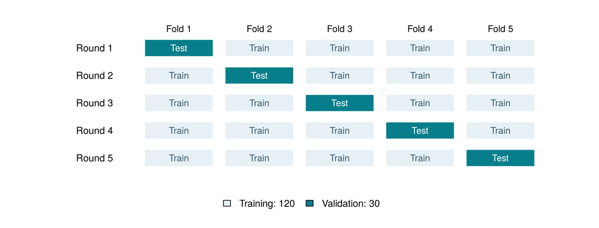

圖 2 一次分層 5-fold 的設計示意。每列是一輪配適，深色區塊為該輪驗證資料；整個過程重新分組做 10 次。

上圖是一次完整的 5-fold。整個過程再**重新隨機分組，重複 10 次**（共 50 輪 train／test）：只切一次，結果可能剛好受某一種分法影響；重複 10 次取平均比較穩。兩種方法每一次都用同一組分法。

折數（5）與次數（10）都固定、不開放調整：每一類至少要有 5 筆，才能讓每一份 test set 都有這一類；不足時停止，不減少折數。

主要指標為 **Macro recall**：先算每一類各自被答對的比例，再取平均。

$$\text{Macro recall}=\frac{1}{K}\sum_{k=1}^{K}\frac{TP_k}{TP_k+FN_k}$$

其中 $TP_k$ 是第 $k$ 類被正確分到第 $k$ 類的筆數，$FN_k$ 是第 $k$ 類被分錯的筆數。

| 例子：A 類 90 筆、B 類 10 筆 | 整體正確率 | Macro recall |
| --- | --- | --- |
| 模型把全部分到 A | 90% | (100% + 0%) ÷ 2 = 50% |

整體正確率會被大類別撐高，Macro recall 則讓每一類一樣重要。另呈現整體正確率與混淆矩陣。補值等前處理必須在各折訓練資料內估計，不能在交叉驗證前用全部資料先補好。

## 10｜怎麼選 LDA 或 QDA：看 test 表現

兩種方法都算得出來時，依上一節的交叉驗證結果，用下面的規則選方法：

| 規則 | 說明 |
| --- | --- |
| 誰考得好就用誰 | 比較每一類各自答對比例的平均（Macro recall），避免大類別把分數撐高 |
| 重複 10 次取平均 | 兩種方法用**相同的分層 5-fold、重複 10 次**（每次重新隨機分組），比較 10 次的平均 Macro recall，較高者勝出；完全相同時選較簡單的 LDA |
| 要考完 10 次才算 | 某個方法有任何一次、任何一折算不出來，就標為「驗證不完整」，不參加比較 |
| 看勝出次數說明穩定度 | 報告寫出 10 次中各贏幾次；落後的方法也贏了好幾次時，明說兩者表現接近，**不代表較高者真的比較好** |
| 選定後建立最終模型 | 用全部分析資料重新配適選中的方法，作為最終模型；交叉驗證分數只用來比較，不是獨立測試表現 |

**為什麼不用 Box’s M 決定？**  
Box’s M 只能回答「各類共變異數矩陣一不一樣」，但我們真正想知道的是「哪個方法分得比較準」，這是兩件事。  
而且它常常太敏感：資料形狀不夠像鐘形時容易顯著；資料筆數越多，也越容易偵測到很小的差異。  
就算各類真的不一樣，QDA 要多估很多數字，資料不夠多時反而容易估歪，分得比 LDA 還差。  
所以我們不靠檢定猜，而是讓兩個方法考同一份試，誰答對得多就用誰。

平均分數的差距與勝出次數只描述這組資料的結果，不當成統計優越性或獨立測試結果。

## 11｜iris 實作驗證與成果

### 資料與探索圖

示範資料有 **150 筆、3 類別、4 個預測變數**。Y 為 `Species`；X 為花萼與花瓣的長、寬，測量單位為公分。固定 seed＝2026，以同一份資料與折別比較 LDA／QDA。

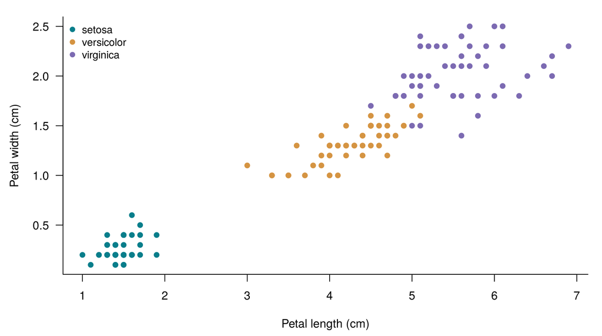

圖 3 花瓣長度與寬度的分組散布圖。這是四個 X 中兩個欄位的視覺化，不是四維分類邊界。

setosa 和另外兩種花分得很開，versicolor 和 virginica 有部分重疊。

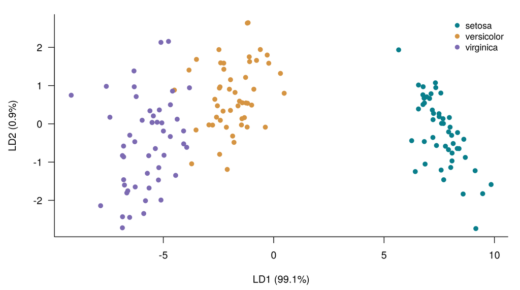

圖 4 LDA 判別分數圖（用全部 150 筆、4 個 X 配適）。LDA 把 4 個測量值組合成判別軸 LD1、LD2；括號內是各軸占判別資訊的比例，不是正確率。此圖只描述類別分得多開，不代表驗證表現。

和圖 3 只看兩個欄位不同，這張圖用到全部 4 個測量值。判別資訊有 **99.1%** 集中在 LD1：setosa 在 LD1 上和另外兩類完全分開；versicolor 和 virginica 在 LD1 上有一小段重疊，重疊區的花就容易被分錯，與後面混淆矩陣中「誤判都發生在這兩類之間」一致。

### 假設診斷

| 檢查 | 類別 | n | 統計量 | p 值 |
| --- | --- | --- | --- | --- |
| Mardia Skewness | setosa | 50 | 25.66 | 0.1772 |
| Mardia Kurtosis | setosa | 50 | 1.295 | 0.1953 |
| Mardia Skewness | versicolor | 50 | 25.19 | 0.1944 |
| Mardia Kurtosis | versicolor | 50 | -0.5719 | 0.5674 |
| Mardia Skewness | virginica | 50 | 26.27 | 0.1571 |
| Mardia Kurtosis | virginica | 50 | 0.1526 | 0.8787 |
| Box M | ALL | 150 | 140.9 | 3.352e-20 |

本例各組 Mardia p 值介於 **0.157～0.879**，在 0.05 水準未拒絕常態假設，但不能說已證明常態。Box’s M 的 p 值為 **3.352e-20**，提示共變異數同質性有疑慮。合併解讀落在「Mardia 不顯著、Box’s M 顯著」：QDA 有機會較好，但仍要看 test 表現。

### 模型表現

LDA｜10 次平均 Macro recall

97.93%

平均答對 146.9 / 150 筆（146–147）

QDA｜10 次平均 Macro recall

97.33%

平均答對 146.0 / 150 筆（145–147）

本例三組樣本數相同，正確率與 Macro recall 數值一致。10 次中 **LDA 較高 6 次、QDA 較高 0 次、相同 4 次**；LDA 平均多答對 0.9 筆，依規則選平均 Macro recall 較高的 LDA。QDA 一次都沒有贏過，但差距很小，不能據此宣稱統計優越性。

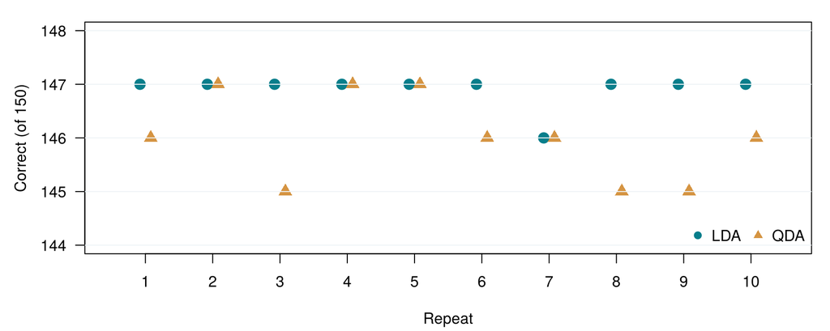

圖 5 10 次重複中兩種方法各自答對的筆數；每一次兩者使用同一組分法。

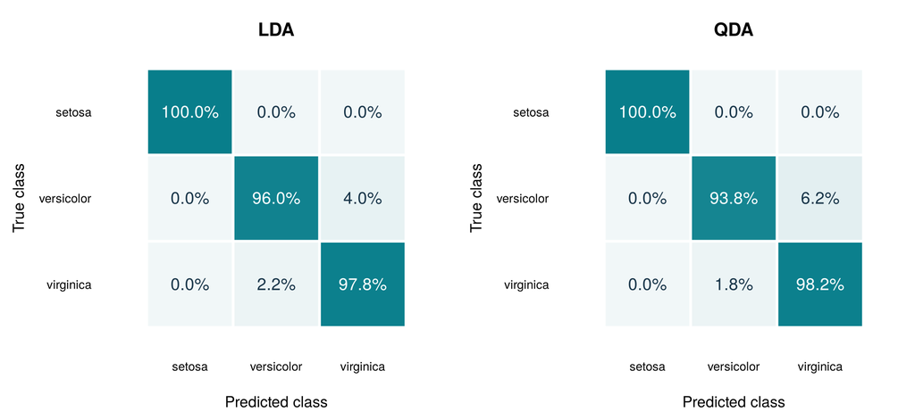

圖 6 混淆矩陣（10 次合併）：列為真實類別，欄為預測類別；數字是該真實類別被預測成各類的百分比，每列加總 100%。

| 類別 | LDA | QDA |
| --- | --- | --- |
| setosa | 100.00% | 100.00% |
| versicolor | 96.00% | 93.80% |
| virginica | 97.80% | 98.20% |

**本次選擇：LDA**  
10 次平均：LDA 答對 146.9 筆、QDA 答對 146.0 筆，依規則選平均 Macro recall 較高的 LDA，並用全部 150 筆重新配適作為最終模型。Box’s M 顯著，但 QDA 並沒有因此分得比較準；報告仍會揭露共變異數同質性的疑慮。平均差距不到 1 筆，不能說 LDA 在統計上較優。尚未執行獨立測試或機率校準。

### 第二個示範：有遺失值的資料

把 iris 隨機挖掉 5% 的測量值（30 格，每列最多 1 格），示範關卡 D 與補值流程。

| 項目 | 結果 |
| --- | --- |
| 遺失值數 | 30 格（分散在 4 個欄位） |
| 不加補值選項時 | 停止並要求先詢問使用者 |
| LDA 答對 | 平均 141.0 / 150（139–143），平均 Macro recall 94.00% |
| QDA 答對 | 平均 143.3 / 150（140–145），平均 Macro recall 95.53% |
| 10 次勝出次數 | LDA 1 次、QDA 8 次、相同 1 次 |
| 選擇 | QDA |

使用者在關卡 D 選擇補值後，程式在每一份 train set 內計算各欄中位數，再補該輪的 train set 與 test set；50 輪各自用的中位數都記錄在 `imputation.csv`。這個示範中 QDA 平均較高，10 次中贏了 8 次，依規則選 QDA；但 LDA 也贏了 1 次，報告會照實寫出。兩個示範合起來看：Box’s M 都沒有決定方法，選擇完全由相同切分的 test 表現決定。

## 12｜限制與貢獻

**限制**

- 只處理「每一筆都是不同對象」的資料；同一對象有多筆時會暫停，本版沒有分組驗證或時間切分。
- 固定分層 5-fold 重複 10 次，每一類至少 5 筆；同一組交叉驗證同時用來比較模型，分數不是獨立測試表現，也沒有機率校準。
- 選模看 10 次的平均 Macro recall；勝出次數只描述穩定度，不是檢定，差距很小時不代表較高者真的較好。
- 補值只提供中位數一種，且只在使用者同意後執行；診斷、描述統計與 skill 報告中的探索圖（報告的圖 1–5）只用完整觀測，模型分數與混淆矩陣包含全部觀測（補值後）。
- 判斷欄位只接受數值型變數。
- 兩個示範通過、驗收通過，不代表所有資料都適用。

**註釋報告重點**

這個 Skill 的成果，不只有分類分數，也包含：明確的分析路徑、會停下來問人的關卡與白話選項、不洩漏的驗證與補值、實際計算依據，以及可追溯的限制與失敗紀錄。

## 13｜參考資料

**原始文獻**

- Fisher, R. A. (1936). The use of multiple measurements in taxonomic problems. *Annals of Eugenics*, 7(2), 179–188.
- Box, G. E. P. (1949). A general distribution theory for a class of likelihood criteria. *Biometrika*, 36(3/4), 317–346.
- Mardia, K. V. (1970). Measures of multivariate skewness and kurtosis with applications. *Biometrika*, 57(3), 519–530.

**教科書**（作者官方網站提供免費 PDF）

- Hastie, T., Tibshirani, R., & Friedman, J. (2009). *The Elements of Statistical Learning* (2nd ed.), §4.3 線性與二次區別分析. Springer. [官方網站](https://hastie.su.domains/ElemStatLearn/)
- James, G., Witten, D., Hastie, T., & Tibshirani, R. (2021). *An Introduction to Statistical Learning with Applications in R* (2nd ed.), §4.4 LDA 與 QDA. Springer. [官方網站](https://www.statlearning.com/)

**軟體文件與資料**

- [MASS：LDA 官方文件](https://stat.ethz.ch/R-manual/R-devel/library/MASS/html/lda.html)、[MASS：QDA 官方文件](https://stat.ethz.ch/R-manual/R-devel/library/MASS/html/qda.html)
- 實作比對：[biotools::boxM](https://search.r-project.org/CRAN/refmans/biotools/html/boxM.html)、[MVN::mardia](https://github.com/selcukorkmaz/MVN/blob/master/R/mardia.R)
- [scikit-learn：交叉驗證與分組切分](https://scikit-learn.org/stable/modules/cross_validation.html)、[常見陷阱：資料洩漏](https://scikit-learn.org/stable/common_pitfalls.html)
- [R：iris 資料來源與欄位](https://stat.ethz.ch/R-manual/R-devel/library/datasets/html/iris.html)

附錄

## 附錄 A｜在 Claude 上使用這個 skill

在 Claude 網頁版或 App 上依下列步驟操作，不需要自己寫程式。

| 步驟 | 怎麼做 |
| --- | --- |
| 1. 下載 skill | 到本專案的 GitHub 頁面下載 `lda-qda.zip`，**不用解壓縮**。壓縮檔裡是一個 `lda-qda/` 資料夾，`SKILL.md` 就在這個資料夾裡 |
| 2. 打開程式執行功能 | 在 Claude 的「Settings → Capabilities」打開「Code execution and file creation」（新版設定稱為「Create and edit files」）。skill 需要執行程式，這一項必須開啟 |
| 3. 上傳 skill | 到「Customize → Skills」，按「＋」→「Create skill」→「Upload a skill」，選擇剛才的 zip；上傳後確認它在清單中是開啟的 |
| 4. 開始分析 | 開一個新對話，上傳資料（CSV 檔，每一列一筆資料、第一列是欄位名稱），輸入「幫我用這份資料做區別分析」 |
| 5. 回答 Claude 的問題 | 沒說明要分類哪一欄時，Claude 會先問；接著列出打算用來判斷的欄位請你確認，如果資料看起來像同一個對象有好幾筆（例如編號重複、有日期欄位），會先確認；有完全相同的列時也會告訴你。X 有遺失值時會問要不要補中位數；Y 有遺失值則會停止並說明 |
| 6. 拿到結果 | 中文分析報告 `report.html`、含 R 程式碼的報告原始檔 `report.qmd`，以及圖和表格。`report.qmd` 要和同資料夾的 `run_analysis.R`、`input_data.csv` 放在一起才能 Render，請下載整個輸出資料夾，不要只拿 qmd |

**注意事項**  
① 本 Skill 使用 R 進行統計分析，需確認執行環境支援 R 及必要套件。若目前環境不支援，則需改在已安裝 R 的環境執行，例如使用 Claude Code 搭配本機 R。  
② 依 Claude 官方說明，Free、Pro、Max、Ultra、Team、Enterprise 方案都可以使用 skills。Team、Enterprise 帳號若找不到上傳選項，可能是管理員關閉了這項功能，請洽管理員。  
③ 想先看看結果長什麼樣子，可以下載 GitHub 上的 `lda-qda/demo_iris/report.html`，再用瀏覽器開啟（GitHub 網頁只會顯示 HTML 原始碼），那是用 iris 實際跑出來的報告。  
④ 官方操作說明：[Use skills in Claude](https://support.claude.com/en/articles/12512180-use-skills-in-claude)、[How to create custom skills](https://support.claude.com/en/articles/12512198)。介面名稱可能隨版本調整，以官方說明為準。

## 附錄 B｜可重現性與驗收

本頁在 Render 時重新讀取示範 CSV、呼叫既有分析函式，表格與圖形由 R 實際生成；流程圖以內嵌 SVG 呈現，可離線閱讀，不依賴線上 Mermaid 服務。

| 保存項目 | 用途 |
| --- | --- |
| 資料內容、列順序、Y／X 與類別順序 | 確認比較的是相同資料與設定 |
| seed、折別、折外類別及機率 | 重現驗證，核對指標 |
| 模型、先驗設定、R 與套件版本 | 交代模型建立條件 |
| 診斷狀態、失敗原因與輸出狀態 | 區分有執行、有成功與有保存 |

`tests/validate.R` 完成 148 項程式驗收（含 Mardia／Box’s M 與 MVN 6.3／biotools 4.3 實測值比對、合併解讀與自動註記、命令列入口、重複交叉驗證、各折補值不洩漏、選擇規則、驗證不完整的處理、固定 5 折 × 10 次與停止條件），並做過一次依參考文件執行的完整 iris 試跑；這份報告另外重新計算示範結果。**程式驗收、示範資料通過與所有資料皆適用，是不同的驗證範圍。**

## 附錄 C｜LDA 與 QDA 的判別函數

兩者都來自「分到機率最大的那一類」（Bayes 規則），再假設每一類是多元常態 $N_p(\boldsymbol\mu_k,\boldsymbol\Sigma_k)$；$\pi_k$ 是第 $k$ 類的先驗機率。新資料 $\mathbf x$ 分到判別分數 $\delta_k(\mathbf x)$ 最大的那一類。

**QDA**：每一類有自己的共變異數矩陣 $\boldsymbol\Sigma_k$，

$$\delta_k^{Q}(\mathbf x)=-\tfrac12\log|\boldsymbol\Sigma_k|-\tfrac12(\mathbf x-\boldsymbol\mu_k)^\top\boldsymbol\Sigma_k^{-1}(\mathbf x-\boldsymbol\mu_k)+\log\pi_k .$$

**LDA**：再假設所有類別共用 $\boldsymbol\Sigma_k=\boldsymbol\Sigma$，含 $\mathbf x^\top\boldsymbol\Sigma^{-1}\mathbf x$ 的二次項對每一類都一樣而消去，判別函數變成 $\mathbf x$ 的線性函數，分界因此是直線（超平面）：

$$\delta_k^{L}(\mathbf x)=\mathbf x^\top\boldsymbol\Sigma^{-1}\boldsymbol\mu_k-\tfrac12\boldsymbol\mu_k^\top\boldsymbol\Sigma^{-1}\boldsymbol\mu_k+\log\pi_k .$$

Box’s M 檢定的就是 $\boldsymbol\Sigma_1=\cdots=\boldsymbol\Sigma_K$ 是否成立。估計量、Mardia 與 Box’s M 的完整公式見 `references/lda-qda-guide.md`。

多變量分析（區別分析）｜LDA／QDA Skill 流程設計與實作驗證